# Meta-analysis physiological costs of hibernation: Report 1 - OS

Pablo Capilla-Lasheras

2025-04-07

This [R Markdown](http://rmarkdown.rstudio.com) Notebook contains the initial meta-analysis for the project ‘physiological ’costs’ of hibernation.

## Dataset and calculation of effect sizes

The dataset for this meta-analysis has been collected after a literature search by Pablo Burraco, Marko Prokic and Tamara Petrovic. It contains data on physiological effects of hibernation in different systems. Here a quick snapshot of the first lines of the dataset:

|  | Reference | Year | Study_ID | Species | Family | Genus | Common.name | Type_of_animal | Thermoregulation | Class | Class_2 | Ver_Invert | Developmental_stage | Location | Experiment_venue | Biological.process | Tissue | Experimental_manipulation | Experimental.value | Biomarker_category | Biomarker_cat_2 | Biomarker_cat_3 | Specific_biomarker | Unit | Euthermia_N | Euthermia_M | Euthermia_SD | Euthermia_SE | Hib_N | … |
| --- | --- | --- | --- | --- | --- | --- | --- | --- | --- | --- | --- | --- | --- | --- | --- | --- | --- | --- | --- | --- | --- | --- | --- | --- | --- | --- | --- | --- | --- | --- |
| 1 | Afifi and Alkaladi, 2014 | 2014 | study 32 | Uromastyx ornata | Agamidae | Uromastyx | ornate mastigure | Lizard | Ectothermic | Reptilia | Reptilia | Vertebrate | adults | Saudi Arabia | Field | hibernation | BAT | NA | male | Non-enzymatic | Antioxidant | Non-enzymatic | Vit E | mg/L homogenate | 10 | 1.220000e+03 | NA | 1.300000e+02 | 10 | … |
| 2 | Afifi and Alkaladi, 2014 | 2014 | study 32 | Uromastyx ornata | Agamidae | Uromastyx | ornate mastigure | Lizard | Ectothermic | Reptilia | Reptilia | Vertebrate | adults | Saudi Arabia | Field | hibernation | blood serum | NA | male | Non-enzymatic | Antioxidant | Non-enzymatic | Vit E | mg/L homogenate | 10 | 4.500000e+02 | NA | 3.600000e+01 | 10 | … |
| 3 | Afifi and Alkaladi, 2014 | 2014 | study 32 | Uromastyx ornata | Agamidae | Uromastyx | ornate mastigure | Lizard | Ectothermic | Reptilia | Reptilia | Vertebrate | adults | Saudi Arabia | Field | hibernation | brain | NA | male | Non-enzymatic | Antioxidant | Non-enzymatic | Vit E | mg/L homogenate | 10 | 1.600000e+03 | NA | 2.540000e+02 | 10 | … |
| 4 | Afifi and Alkaladi, 2014 | 2014 | study 32 | Uromastyx ornata | Agamidae | Uromastyx | ornate mastigure | Lizard | Ectothermic | Reptilia | Reptilia | Vertebrate | adults | Saudi Arabia | Field | hibernation | liver | NA | male | Non-enzymatic | Antioxidant | Non-enzymatic | Vit E | mg/L homogenate | 10 | 1.676000e+03 | NA | 1.720000e+02 | 10 | … |
| 5 | Afifi and Alkaladi, 2014 | 2014 | study 32 | Uromastyx ornata | Agamidae | Uromastyx | ornate mastigure | Lizard | Ectothermic | Reptilia | Reptilia | Vertebrate | adults | Saudi Arabia | Field | hibernation | BAT | NA | male | Enzymatic | Antioxidant | Enzymatic | GPx | μM /min/g tissue | 10 | 4.460000e+01 | NA | 2.300000e+00 | 10 | … |
| 6 | Afifi and Alkaladi, 2014 | 2014 | study 32 | Uromastyx ornata | Agamidae | Uromastyx | ornate mastigure | Lizard | Ectothermic | Reptilia | Reptilia | Vertebrate | adults | Saudi Arabia | Field | hibernation | brain | NA | male | Enzymatic | Antioxidant | Enzymatic | GR | unit/g tissue | 10 | 4.440000e+01 | NA | 4.400000e+00 | 10 | … |
| 7 | Afifi and Alkaladi, 2014 | 2014 | study 32 | Uromastyx ornata | Agamidae | Uromastyx | ornate mastigure | Lizard | Ectothermic | Reptilia | Reptilia | Vertebrate | adults | Saudi Arabia | Field | hibernation | liver | NA | male | Enzymatic | Antioxidant | Enzymatic | GR | unit/g tissue | 10 | 5.700000e+01 | NA | 5.000000e+00 | 10 | … |
| 8 | Afifi and Alkaladi, 2014 | 2014 | study 32 | Uromastyx ornata | Agamidae | Uromastyx | ornate mastigure | Lizard | Ectothermic | Reptilia | Reptilia | Vertebrate | adults | Saudi Arabia | Field | hibernation | blood serum | NA | male | Enzymatic | Antioxidant | Enzymatic | GPx | μM /min/g tissue | 10 | 3.540000e+01 | NA | 3.900000e+00 | 10 | … |
| 9 | Afifi and Alkaladi, 2014 | 2014 | study 32 | Uromastyx ornata | Agamidae | Uromastyx | ornate mastigure | Lizard | Ectothermic | Reptilia | Reptilia | Vertebrate | adults | Saudi Arabia | Field | hibernation | liver | NA | male | Enzymatic | Antioxidant | Enzymatic | GPx | μM /min/g tissue | 10 | 4.200000e+01 | NA | 4.000000e+00 | 10 | … |
| 10 | Afifi and Alkaladi, 2014 | 2014 | study 32 | Uromastyx ornata | Agamidae | Uromastyx | ornate mastigure | Lizard | Ectothermic | Reptilia | Reptilia | Vertebrate | adults | Saudi Arabia | Field | hibernation | brain | NA | male | Enzymatic | Antioxidant | Enzymatic | GPx | μM /min/g tissue | 10 | 4.140000e+01 | NA | 2.300000e+00 | 10 | … |

[output cut: 1012 more lines]

As a summary of the *initial dataset*:

- Number of studies: 61
- Number of species: 29

For this initial meta-analysis, I am going to include all oxidative stress (OS) markers and calculate the standarised mean difference (g; with heteroscedastic population variances) as the effect size of analysis comparing **hibernation** *versus* **euthermia**. Positive SMD values indicate higher OS values in *hibernation* while negative SMD indicate lower OS values in hibernation. This is a summary of the effect size calculation based on the dataset above:

Summary of SMD effect size and number of observations included in the meta-analysis:

```
##      Min.   1st Qu.    Median      Mean   3rd Qu.      Max.
## -7.846502 -1.030992  0.035193  0.007249  0.904472 14.475723
```

- Number of observation with non-missing SMD: 845
- Number of studies in the dataset for analysis: 54
- Number of species in the dataset for analysis: 27

## Initial meta-analysis:

This initial model contains only the intercept and five random effects to account for variation between between classes, families, species, between studies and within studies beyond sampling variance.

```r
model_SMD <- rma.mv(yi = SMDH,
                     V = SMDH.sv,
                     mods = ~ 1,
                     random = list(~1|Study_ID,
                                   ~1|Class,
                                   ~1|Family,
                                   ~1|Species,
                                   ~1|obsID),
                     data=df_SMD,
                     method="REML")
```

```
##
## Multivariate Meta-Analysis Model (k = 845; method: REML)
##
##     logLik    Deviance         AIC         BIC        AICc
## -1573.1777   3146.3554   3158.3554   3186.7843   3158.4557
##
## Variance Components:
##
##             estim    sqrt  nlvls  fixed    factor
## sigma^2.1  0.4135  0.6430     54     no  Study_ID
## sigma^2.2  0.0282  0.1679      7     no     Class
## sigma^2.3  0.0000  0.0001     19     no    Family
## sigma^2.4  0.0000  0.0001     27     no   Species
## sigma^2.5  1.1437  1.0694    845     no     obsID
##
## Test for Heterogeneity:
## Q(df = 844) = 3146.9351, p-val < .0001
##
## Model Results:
##
## estimate      se     zval    pval    ci.lb   ci.ub
##  -0.1157  0.1471  -0.7869  0.4313  -0.4040  0.1725
##
## ---
## Signif. codes:  0 '***' 0.001 '**' 0.01 '*' 0.05 '.' 0.1 ' ' 1
```

Proportion of variation left after accounting for sampling variance and proportion accounted by each random effect:

| Variable | i2_value_percentage |
| --- | --- |
| I2_Total | 78.856 |
| I2_Study_ID | 20.567 |
| I2_Class | 1.402 |
| I2_Family | 0.000 |
| I2_Species | 0.000 |
| I2_obsID | 56.887 |

### Plot of results of intercept-only model:

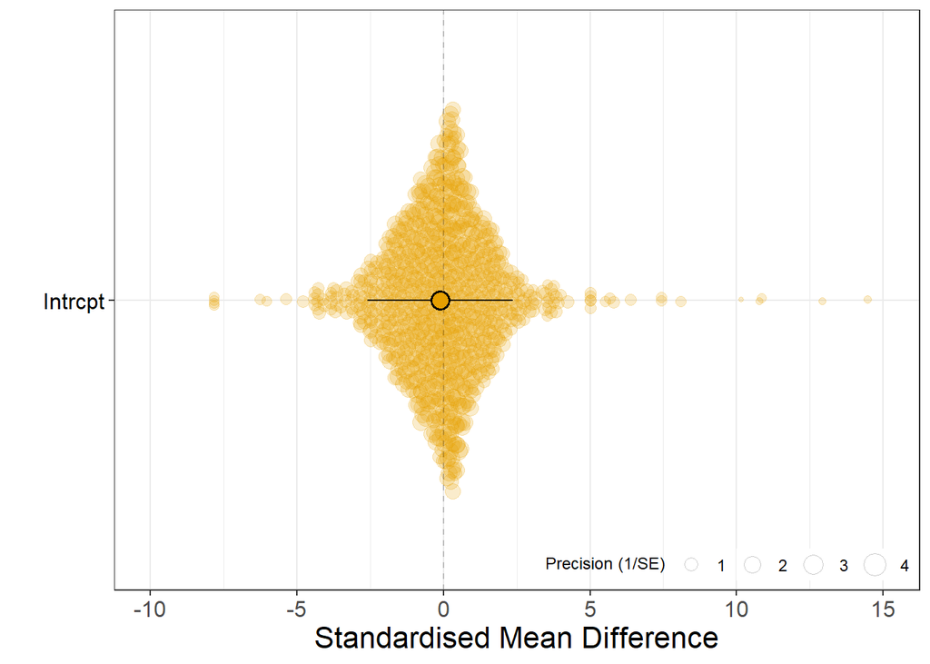

### Publication bias: small-study effects

```
##
## Multivariate Meta-Analysis Model (k = 845; method: REML)
##
##     logLik    Deviance         AIC         BIC        AICc
## -1571.1271   3142.2541   3156.2541   3189.4129   3156.3883
##
## Variance Components:
##
##             estim    sqrt  nlvls  fixed    factor
## sigma^2.1  0.4537  0.6736     54     no  Study_ID
## sigma^2.2  0.0001  0.0092      7     no     Class
## sigma^2.3  0.0000  0.0014     19     no    Family
## sigma^2.4  0.0000  0.0025     27     no   Species
## sigma^2.5  1.1440  1.0696    845     no     obsID
##
## Test for Residual Heterogeneity:
## QE(df = 843) = 3146.9342, p-val < .0001
##
## Test of Moderators (coefficient 2):
## QM(df = 1) = 0.3831, p-val = 0.5359
##
## Model Results:
##
##                   estimate      se     zval    pval    ci.lb   ci.ub
## intrcpt            -0.4759  0.5922  -0.8036  0.4216  -1.6367  0.6849
## sqrt(inv_eff_ss)    0.6282  1.0150   0.6190  0.5359  -1.3611  2.6175
##
## ---
## Signif. codes:  0 '***' 0.001 '**' 0.01 '*' 0.05 '.' 0.1 ' ' 1
```

```
##    R2_marginal R2_conditional
##    0.002120093    0.285533111
```

### Publication bias: time-lag effects

```
##
## Multivariate Meta-Analysis Model (k = 845; method: REML)
##
##     logLik    Deviance         AIC         BIC        AICc
## -1569.1129   3138.2258   3152.2258   3185.3846   3152.3600
##
## Variance Components:
##
##             estim    sqrt  nlvls  fixed    factor
## sigma^2.1  0.3110  0.5577     54     no  Study_ID
## sigma^2.2  0.0594  0.2437      7     no     Class
## sigma^2.3  0.0000  0.0001     19     no    Family
## sigma^2.4  0.0000  0.0001     27     no   Species
## sigma^2.5  1.1497  1.0722    845     no     obsID
##
## Test for Residual Heterogeneity:
## QE(df = 843) = 3071.2892, p-val < .0001
##
## Test of Moderators (coefficient 2):
## QM(df = 1) = 4.6788, p-val = 0.0305
##
## Model Results:
##
##              estimate      se     zval    pval    ci.lb   ci.ub
## intrcpt       -0.0988  0.1632  -0.6052  0.5450  -0.4187  0.2211
## scale(Year)    0.2090  0.0966   2.1631  0.0305   0.0196  0.3984  *
##
## ---
## Signif. codes:  0 '***' 0.001 '**' 0.01 '*' 0.05 '.' 0.1 ' ' 1
```

```
##    R2_marginal R2_conditional
##     0.02793995     0.26481469
```

## Meta-analysis with all organisms but including different OS markers:

Number of observations for each type:

```
##
##      Antioxidant Oxidative_damage       Regulatory              ROS
##              663              123               34               25
```

```
##
## Multivariate Meta-Analysis Model (k = 845; method: REML)
##
##     logLik    Deviance         AIC         BIC        AICc
## -1560.5205   3121.0410   3139.0410   3181.6523   3139.2576
##
## Variance Components:
##
##             estim    sqrt  nlvls  fixed    factor
## sigma^2.1  0.3590  0.5992     54     no  Study_ID
## sigma^2.2  0.0295  0.1718      7     no     Class
## sigma^2.3  0.0000  0.0008     19     no    Family
## sigma^2.4  0.0000  0.0014     27     no   Species
## sigma^2.5  1.1261  1.0612    845     no     obsID
##
## Test for Residual Heterogeneity:
## QE(df = 841) = 3095.5371, p-val < .0001
##
## Test of Moderators (coefficients 1:4):
## QM(df = 4) = 18.4376, p-val = 0.0010
##
## Model Results:
##
##                                  estimate      se     zval    pval    ci.lb
## Biomarker_cat_2Antioxidant        -0.2137  0.1462  -1.4614  0.1439  -0.5004
## Biomarker_cat_2Oxidative_damage    0.1571  0.1836   0.8555  0.3923  -0.2028
## Biomarker_cat_2Regulatory          0.6393  0.3030   2.1101  0.0348   0.0455
## Biomarker_cat_2ROS                -0.5338  0.3003  -1.7775  0.0755  -1.1223
##                                   ci.ub
## Biomarker_cat_2Antioxidant       0.0729
## Biomarker_cat_2Oxidative_damage  0.5169
## Biomarker_cat_2Regulatory        1.2330  *
## Biomarker_cat_2ROS               0.0548  .
##
## ---
## Signif. codes:  0 '***' 0.001 '**' 0.01 '*' 0.05 '.' 0.1 ' ' 1
```

```
##
## Multivariate Meta-Analysis Model (k = 845; method: REML)
##
##     logLik    Deviance         AIC         BIC        AICc
## -1560.5205   3121.0410   3139.0410   3181.6523   3139.2576
##
## Variance Components:
##
##             estim    sqrt  nlvls  fixed    factor
## sigma^2.1  0.3590  0.5992     54     no  Study_ID
## sigma^2.2  0.0295  0.1718      7     no     Class
## sigma^2.3  0.0000  0.0008     19     no    Family
## sigma^2.4  0.0000  0.0014     27     no   Species
## sigma^2.5  1.1261  1.0612    845     no     obsID
##
## Test for Residual Heterogeneity:
## QE(df = 841) = 3095.5371, p-val < .0001
##
## Test of Moderators (coefficients 1:4):
## QM(df = 4) = 18.4376, p-val = 0.0010
##
## Model Results:
##
##                                  estimate      se     zval    pval    ci.lb
## Biomarker_cat_2Antioxidant        -0.2137  0.1462  -1.4614  0.1439  -0.5004
## Biomarker_cat_2Oxidative_damage    0.1571  0.1836   0.8555  0.3923  -0.2028
## Biomarker_cat_2Regulatory          0.6393  0.3030   2.1101  0.0348   0.0455
## Biomarker_cat_2ROS                -0.5338  0.3003  -1.7775  0.0755  -1.1223
##                                   ci.ub
## Biomarker_cat_2Antioxidant       0.0729
## Biomarker_cat_2Oxidative_damage  0.5169
## Biomarker_cat_2Regulatory        1.2330  *
## Biomarker_cat_2ROS               0.0548  .
##
## ---
## Signif. codes:  0 '***' 0.001 '**' 0.01 '*' 0.05 '.' 0.1 ' ' 1
```

### Plot of results of biomarker meta-regression:

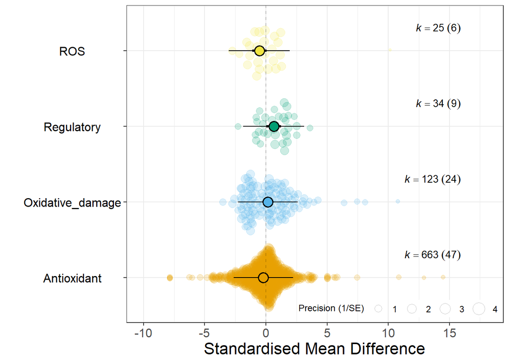

## Meta-analysis including thermoregulation type as a moderator:

Number of observations for each type:

```
##
## Ectothermic Endothermic
##         347         498
```

```
##
## Multivariate Meta-Analysis Model (k = 845; method: REML)
##
##     logLik    Deviance         AIC         BIC        AICc
## -1570.6407   3141.2813   3155.2813   3188.4401   3155.4155
##
## Variance Components:
##
##             estim    sqrt  nlvls  fixed    factor
## sigma^2.1  0.4000  0.6325     54     no  Study_ID
## sigma^2.2  0.0909  0.3015      7     no     Class
## sigma^2.3  0.0000  0.0000     19     no    Family
## sigma^2.4  0.0000  0.0001     27     no   Species
## sigma^2.5  1.1450  1.0700    845     no     obsID
##
## Test for Residual Heterogeneity:
## QE(df = 843) = 3097.0667, p-val < .0001
##
## Test of Moderators (coefficients 1:2):
## QM(df = 2) = 0.2822, p-val = 0.8684
##
## Model Results:
##
##                              estimate      se     zval    pval    ci.lb   ci.ub
## ThermoregulationEctothermic   -0.1122  0.2324  -0.4826  0.6294  -0.5677  0.3434
## ThermoregulationEndothermic   -0.0738  0.3323  -0.2220  0.8243  -0.7250  0.5775
##
## ThermoregulationEctothermic
## ThermoregulationEndothermic
##
## ---
## Signif. codes:  0 '***' 0.001 '**' 0.01 '*' 0.05 '.' 0.1 ' ' 1
```

```
##
## Multivariate Meta-Analysis Model (k = 845; method: REML)
##
##     logLik    Deviance         AIC         BIC        AICc
## -1570.6407   3141.2813   3155.2813   3188.4401   3155.4155
##
## Variance Components:
##
##             estim    sqrt  nlvls  fixed    factor
## sigma^2.1  0.4000  0.6325     54     no  Study_ID
## sigma^2.2  0.0909  0.3015      7     no     Class
## sigma^2.3  0.0000  0.0000     19     no    Family
## sigma^2.4  0.0000  0.0001     27     no   Species
## sigma^2.5  1.1450  1.0700    845     no     obsID
##
## Test for Residual Heterogeneity:
## QE(df = 843) = 3097.0667, p-val < .0001
##
## Test of Moderators (coefficients 1:2):
## QM(df = 2) = 0.2822, p-val = 0.8684
##
## Model Results:
##
##                              estimate      se     zval    pval    ci.lb   ci.ub
## ThermoregulationEctothermic   -0.1122  0.2324  -0.4826  0.6294  -0.5677  0.3434
## ThermoregulationEndothermic   -0.0738  0.3323  -0.2220  0.8243  -0.7250  0.5775
##
## ThermoregulationEctothermic
## ThermoregulationEndothermic
##
## ---
## Signif. codes:  0 '***' 0.001 '**' 0.01 '*' 0.05 '.' 0.1 ' ' 1
```

### Plot of results of thermoregulation meta-regression:

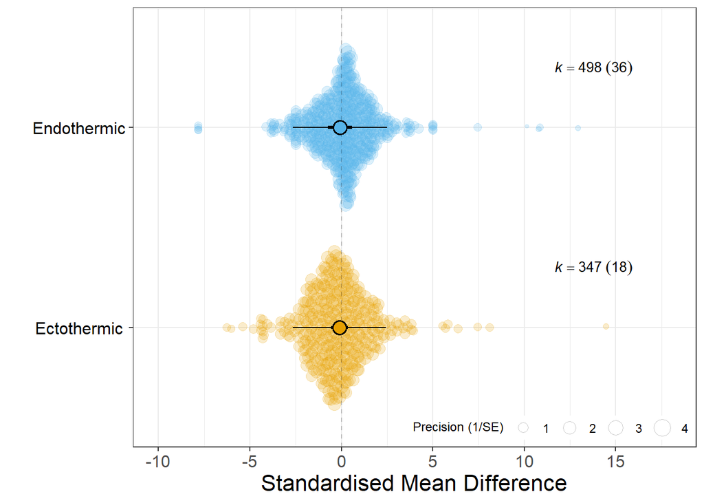

## Endotherms vs. ectotherms:

Now, we investigate if the response to hibernation varies across biomarkers of oxidative stress for endotherms and ectotherms. We include four markers:

```
##
##      Antioxidant Oxidative_damage       Regulatory              ROS
##              663              123               34               25
```

### Meta-model for endotherms:

- Number of observation with non-missing SMD: 498
- Number of studies in the dataset for analysis: 36
- Number of species in the dataset for analysis: 14

```
##
## Multivariate Meta-Analysis Model (k = 498; method: REML)
##
##    logLik   Deviance        AIC        BIC       AICc
## -892.8455  1785.6909  1801.6909  1835.3112  1801.9878
##
## Variance Components:
##
##             estim    sqrt  nlvls  fixed    factor
## sigma^2.1  0.5828  0.7634     36     no  Study_ID
## sigma^2.2  0.0000  0.0000      7     no    Family
## sigma^2.3  0.0000  0.0001     14     no   Species
## sigma^2.4  0.8880  0.9424    498     no     obsID
##
## Test for Residual Heterogeneity:
## QE(df = 494) = 1565.7021, p-val < .0001
##
## Test of Moderators (coefficients 1:4):
## QM(df = 4) = 13.4260, p-val = 0.0094
##
## Model Results:
##
##                                  estimate      se     zval    pval    ci.lb
## Biomarker_cat_2Antioxidant        -0.1147  0.1643  -0.6984  0.4849  -0.4367
## Biomarker_cat_2Oxidative_damage   -0.4644  0.2345  -1.9808  0.0476  -0.9240
## Biomarker_cat_2Regulatory          0.6018  0.2866   2.1001  0.0357   0.0402
## Biomarker_cat_2ROS                -0.5380  0.2856  -1.8838  0.0596  -1.0977
##                                    ci.ub
## Biomarker_cat_2Antioxidant        0.2072
## Biomarker_cat_2Oxidative_damage  -0.0049  *
## Biomarker_cat_2Regulatory         1.1635  *
## Biomarker_cat_2ROS                0.0217  .
##
## ---
## Signif. codes:  0 '***' 0.001 '**' 0.01 '*' 0.05 '.' 0.1 ' ' 1
```

```
##
## Multivariate Meta-Analysis Model (k = 498; method: REML)
##
##    logLik   Deviance        AIC        BIC       AICc
## -892.8455  1785.6909  1801.6909  1835.3112  1801.9878
##
## Variance Components:
##
##             estim    sqrt  nlvls  fixed    factor
## sigma^2.1  0.5828  0.7634     36     no  Study_ID
## sigma^2.2  0.0000  0.0000      7     no    Family
## sigma^2.3  0.0000  0.0001     14     no   Species
## sigma^2.4  0.8880  0.9424    498     no     obsID
##
## Test for Residual Heterogeneity:
## QE(df = 494) = 1565.7021, p-val < .0001
##
## Test of Moderators (coefficients 1:4):
## QM(df = 4) = 13.4260, p-val = 0.0094
##
## Model Results:
##
##                                  estimate      se     zval    pval    ci.lb
## Biomarker_cat_2Antioxidant        -0.1147  0.1643  -0.6984  0.4849  -0.4367
## Biomarker_cat_2Oxidative_damage   -0.4644  0.2345  -1.9808  0.0476  -0.9240
## Biomarker_cat_2Regulatory          0.6018  0.2866   2.1001  0.0357   0.0402
## Biomarker_cat_2ROS                -0.5380  0.2856  -1.8838  0.0596  -1.0977
##                                    ci.ub
## Biomarker_cat_2Antioxidant        0.2072
## Biomarker_cat_2Oxidative_damage  -0.0049  *
## Biomarker_cat_2Regulatory         1.1635  *
## Biomarker_cat_2ROS                0.0217  .
##
## ---
## Signif. codes:  0 '***' 0.001 '**' 0.01 '*' 0.05 '.' 0.1 ' ' 1
```

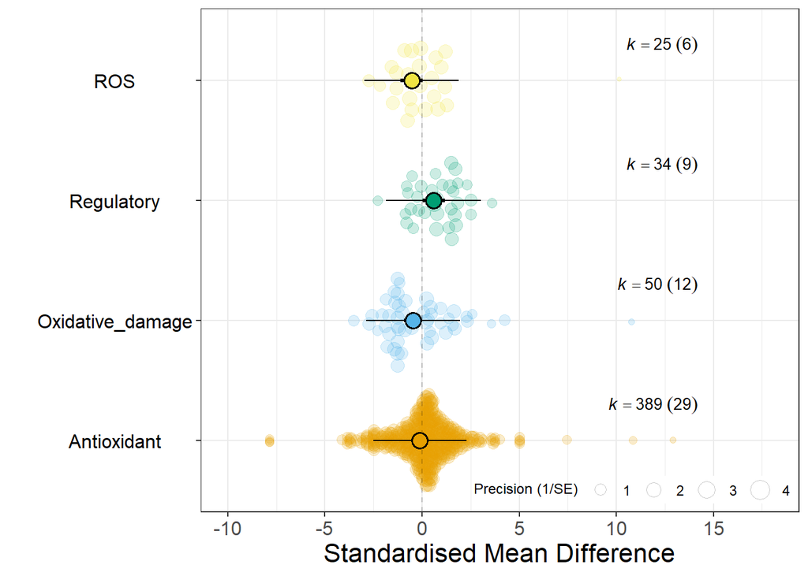

### Meta-model for ectotherms:

- Number of observation with non-missing SMD: 347
- Number of studies in the dataset for analysis: 18
- Number of species in the dataset for analysis: 13

```
##
## Multivariate Meta-Analysis Model (k = 347; method: REML)
##
##    logLik   Deviance        AIC        BIC       AICc
## -649.0228  1298.0456  1312.0456  1338.9504  1312.3780
##
## Variance Components:
##
##             estim    sqrt  nlvls  fixed    factor
## sigma^2.1  0.0000  0.0000     18     no  Study_ID
## sigma^2.2  0.1044  0.3230      6     no     Class
## sigma^2.3  0.0000  0.0004     12     no    Family
## sigma^2.4  0.2422  0.4921     13     no   Species
## sigma^2.5  1.3333  1.1547    347     no     obsID
##
## Test for Residual Heterogeneity:
## QE(df = 345) = 1401.2776, p-val < .0001
##
## Test of Moderators (coefficients 1:2):
## QM(df = 2) = 22.8307, p-val < .0001
##
## Model Results:
##
##                                  estimate      se     zval    pval    ci.lb
## Biomarker_cat_2Antioxidant        -0.3250  0.2291  -1.4189  0.1559  -0.7739
## Biomarker_cat_2Oxidative_damage    0.5517  0.2720   2.0281  0.0425   0.0185
##                                   ci.ub
## Biomarker_cat_2Antioxidant       0.1239
## Biomarker_cat_2Oxidative_damage  1.0848  *
##
## ---
## Signif. codes:  0 '***' 0.001 '**' 0.01 '*' 0.05 '.' 0.1 ' ' 1
```

```
##
## Multivariate Meta-Analysis Model (k = 347; method: REML)
##
##    logLik   Deviance        AIC        BIC       AICc
## -649.0228  1298.0456  1312.0456  1338.9504  1312.3780
##
## Variance Components:
##
##             estim    sqrt  nlvls  fixed    factor
## sigma^2.1  0.0000  0.0000     18     no  Study_ID
## sigma^2.2  0.1044  0.3230      6     no     Class
## sigma^2.3  0.0000  0.0004     12     no    Family
## sigma^2.4  0.2422  0.4921     13     no   Species
## sigma^2.5  1.3333  1.1547    347     no     obsID
##
## Test for Residual Heterogeneity:
## QE(df = 345) = 1401.2776, p-val < .0001
##
## Test of Moderators (coefficients 1:2):
## QM(df = 2) = 22.8307, p-val < .0001
##
## Model Results:
##
##                                  estimate      se     zval    pval    ci.lb
## Biomarker_cat_2Antioxidant        -0.3250  0.2291  -1.4189  0.1559  -0.7739
## Biomarker_cat_2Oxidative_damage    0.5517  0.2720   2.0281  0.0425   0.0185
##                                   ci.ub
## Biomarker_cat_2Antioxidant       0.1239
## Biomarker_cat_2Oxidative_damage  1.0848  *
##
## ---
## Signif. codes:  0 '***' 0.001 '**' 0.01 '*' 0.05 '.' 0.1 ' ' 1
```

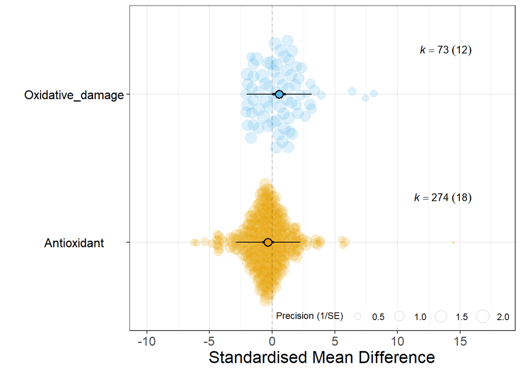